# pavo

#### Categorical Fly Colorspace

The categorical color vision model of Troje (1993) is a model of dipteran vision, based on behavioural data from the blowfly *Lucilia* sp. It assumes the involvement of all four dipteran photoreceptor classes (R7 & R8 ‘pale’ and ‘yellow’ subtypes), and further posits that color vision is based on two specific opponent mechanisms (R7p - R8p, and R7y - R8y). The model assumes that all colors are perceptually grouped into one of four color categories, and that flies are unable to distinguish between colors that fall within the same category.

We’ll use the visual systems of the mudcoid fly *Musca domestica*, and will begin by estimating linear (i.e. untransformed) quantum catches for each of the four photoreceptors.

```r
vis.flowers <- vismodel(flowers, qcatch = 'Qi', visual = 'musca', achro = 'none', relative = TRUE)
```

Our call to `colspace` will then simply estimate the location of stimuli in the categorical space as the difference in relative stimulation between ‘pale’ (R7p - R8p) and ‘yellow’ (R7y - R8y) photoreceptor pairs:

$$x = R7_p - R8_p$$

$$y = R7_y - R8_y$$

```r
cat.flowers <- colspace(vis.flowers, space = 'categorical')

head(cat.flowers)
```

```
##                              R7p        R7y       R8p       R8y          x
## Goodenia_heterophylla 0.05387620 0.18710675 0.4335989 0.3254182 -0.3797227
## Goodenia_geniculata   0.02080100 0.08276037 0.3737596 0.5226791 -0.3529586
## Goodenia_gracilis     0.01153133 0.02501422 0.1420052 0.8214492 -0.1304739
## Xyris_operculata      0.01270355 0.12523436 0.4488383 0.4132238 -0.4361348
## Eucalyptus_sp         0.03461951 0.14207857 0.3977211 0.4255808 -0.3631016
## Faradaya_splendida    0.03599956 0.09188569 0.3129199 0.5591949 -0.2769203
##                                y category     r.vec
## Goodenia_heterophylla -0.1383114     p-y- 0.4041279
## Goodenia_geniculata   -0.4399187     p-y- 0.5640108
## Goodenia_gracilis     -0.7964350     p-y- 0.8070515
## Xyris_operculata      -0.2879894     p-y- 0.5226389
## Eucalyptus_sp         -0.2835023     p-y- 0.4606694
## Faradaya_splendida    -0.4673092     p-y- 0.5431968
```

And it is simply the signs of these differences that define the four possible fly-color categories (p+y+, p-y+, p+y-, p-y-), which we can see in the associated plot.

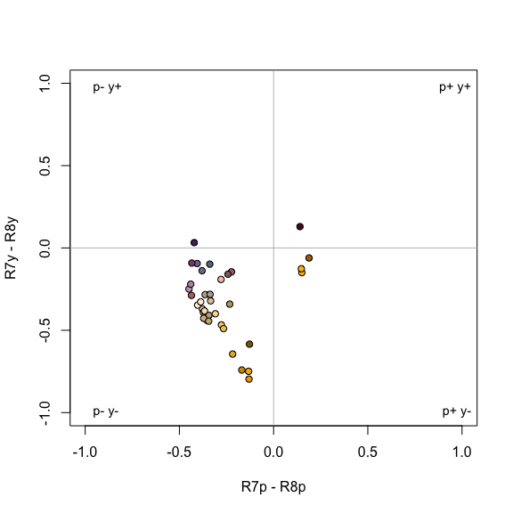

*Flowers in the categorical colorspace of Troje (1993).*

```r
plot(cat.flowers, pch = 21, bg = flowercols)
```

#### Segment Classification

The segment classification analysis (Endler 1990) does not assume any particular visual system, but instead tries to classify colors in a manner that captures common properties of many vertebrate (and some invertebrate) visual systems. In essence, it breaks down the reflectance spectrum region of interest into four equally-spaced regions, measuring the relative signal along those regions. This approximates a tetrachromatic system with ultraviolet, short, medium, and long-wavelength sensitive photoreceptors.

Though somewhat simplistic, this model captures many of the properties of other, more complex visual models, but without many of the additional assumptions these make. It also provides results in a fairly intuitive color space, in which the angle corresponds to hue and the distance from the center corresponds to chroma (Figure below; in fact, variables `S5` and `H4` from `summary.rspec` are calculated from these relative segments). Note that, while a segment analysis ranging from 300 or 400 nm to 700 nm corresponds quite closely to the human visual system color wheel, any wavelength range can be analyzed in this way, returning a 360<sup>o</sup> hue space delimited by the range used.

The segment differences or “opponents” are calculated as:

$$LM = \frac{ R_\lambda \sum_{\lambda={Q4}} R_\lambda - \sum_{\lambda={Q2}} R_\lambda }{\sum_{\lambda={min}}^{max}R_\lambda}$$
$$MS = \frac{ R_\lambda \sum_{\lambda={Q3}} R_\lambda - \sum_{\lambda={Q1}} R_\lambda }{\sum_{\lambda={min}}^{max}R_\lambda}$$

Where $Qi$ represent the interquantile distances (e.g. $Q_1=ultraviolet$, $Q_2=blue$, $Q_3=green$ and $Q_4=red$)

As of vesion `1.1`, the segment classification model is obtained through the `colspace()` argument `space = 'segment'`, following initial modelling with `vismodel()`. The example below uses idealized reflectance spectra to illustrate how the avian color space defined from the segment classification maps to the human color wheel:

```r
fakedata1 <-  sapply(seq(100,500,by = 20),
                     function(x) rowSums(cbind(dnorm(300:700,x,30),
                                               dnorm(300:700,x+400,30))))

# creating idealized specs with varying saturation
fakedata2 <- sapply(c(500, 300, 150, 105, 75, 55, 40, 30),
                     function(x) dnorm(300:700,550,x))

fakedata1 <- as.rspec(data.frame(wl = 300:700, fakedata1))
```

```
## wavelengths found in column 1
```

```r
fakedata1 <- procspec(fakedata1, "max")
```

```
## processing options applied:
## Scaling spectra to a maximum value of 1
```

```r
fakedata2 <- as.rspec(data.frame(wl = 300:700, fakedata2))
```

```
## wavelengths found in column 1
```

```r
fakedata2 <- procspec(fakedata2, "sum")
```

```
## processing options applied:
## Scaling spectra to a total area of 1
```

```r
fakedata2 <- procspec(fakedata2, "min")
```

```
## processing options applied:
## Scaling spectra to a minimum value of zero
```

```r
# converting reflectance to percentage
fakedata1[,-1] <- fakedata1[,-1]*100
fakedata2[,-1] <- fakedata2[,-1]/max(fakedata2[,-1])*100

# combining and converting to rspec
fakedata.c <- data.frame(wl = 300:700, fakedata1[,-1], fakedata2[,-1])
fakedata.c <- as.rspec(fakedata.c)
```

```
## wavelengths found in column 1
```

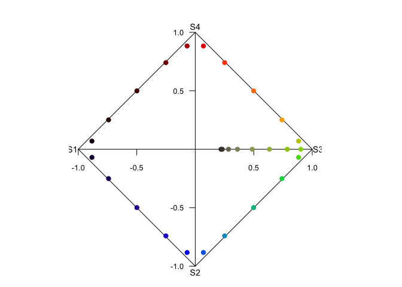

*Idealized reflectance spectra and their projection on the axes of segment classification*

```r
# segment classification analysis
seg.vis <- vismodel(fakedata.c, visual = 'segment', achromatic = 'all')
seg.fdc <- colspace(seg.vis, space = 'segment')

# plot results
plot(seg.fdc, col = spec2rgb(fakedata.c))
```

#### Colorspace Distances with `coldist`

Under the color space framework, color distances can be calculated simply as Euclidean distances of the relative cone stimulation data, either log-transformed or not, depending on how it was defined. However, these distances cannot be interpreted in terms of JNDs, since no receptor noise is incorporated in the model. Euclidean distances can be computed in `R` using the `coldist` function on the `colspace` output:

```r
head(coldist(tetra.flowers))
```

[output not shown]

Specialised colorspace models such as the colour-hexagon, coc space, CIELAB and CIELCH models have their own distance measures, which are returned be default when run through coldist(). Be sure to read the `?coldist` documentation, and the original publications, to understand what is being returned. As an example, if we run the results of colour-hexagon modelling through `coldist`:

```r
# Model flower colours according to a honeybee
vis.flowers <- vismodel(flowers, visual = 'apis', qcatch = 'Ei', relative = FALSE, vonkries = TRUE, achro = 'l', bkg = 'green')
hex.flowers <- colspace(vis.flowers, space = 'hexagon')

# Estimate color distances. No need to specify relative receptor densities, noise etc.,
# which only apply in the case of receptor-noise modelling
dist.flowers <- coldist(hex.flowers)
head(dist.flowers)
```

```
##                  patch1              patch2        dS
## 1 Goodenia_heterophylla Goodenia_geniculata 0.3207265
## 2 Goodenia_heterophylla   Goodenia_gracilis 0.6870945
## 3 Goodenia_heterophylla    Xyris_operculata 0.3025298
## 4 Goodenia_heterophylla       Eucalyptus_sp 0.1111375
## 5 Goodenia_heterophylla  Faradaya_splendida 0.2324927
## 6 Goodenia_heterophylla  Gaultheria_hispida 0.2280836
```

the chromatic constrasts `dS` and achromatic contrasts `dL` are expressed as Euclidean distances in the hexagon, known as ‘hexagon units’ (Chittka 1992). If we had instead used the color-oppoonent coding space the units would have been city-bloc distances, while in the CIELAB model the distances would be derived from the CIE colour-distance formula (2000).

#### Distances in N-Dimensions

As of version `1.0`, the `codist` function is no longer limited to di-, tri- or tetrachromatic visual systems. The function has been generalised, and can now calculate color distances for n-dimensional visual phenotypes. This means there is no limit on the dimensionality of visual systems that may be input, which may prove useful for modelling nature’s extremes (e.g. butterflies, mantis shrimp) or for simulation-based work. Naturally, since these calculations aren’t largely implemented elsewhere, we recommend caution and validation of results prior to publication.

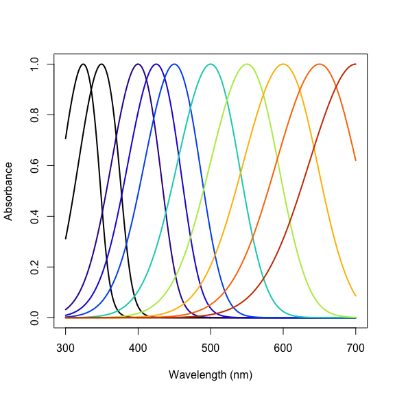

*Visual system of a pretend mantis shrimp with 10 cones*

```r
# Create an arbitrary visual phenotype with 10 photoreceptors
fakemantisshrimp <- sensmodel(c(325, 350, 400, 425, 450, 500, 550, 600, 650, 700), beta = FALSE, integrate = FALSE)

# Convert to percentages, just to color the plot
fakemantisshrimp.colors <- fakemantisshrimp * 100
fakemantisshrimp.colors[, 'wl'] <- fakemantisshrimp[, 'wl']

plot(fakemantisshrimp, col = spec2rgb(fakemantisshrimp.colors), lwd = 2, ylab = 'Absorbance')
```

```r
# Run visual model and calculate color distances
vm.fms <- vismodel(flowers, visual = fakemantisshrimp, relative = FALSE, achro = FALSE)

JND.fms <- coldist(vm.fms, n = c(1, 1, 2, 2, 3, 3, 4, 4, 5, 5))

head(JND.fms)
```

```
##                  patch1              patch2        dS
## 1 Goodenia_heterophylla Goodenia_geniculata 16.297557
## 2 Goodenia_heterophylla   Goodenia_gracilis 48.390309
## 3 Goodenia_heterophylla    Xyris_operculata 30.760482
## 4 Goodenia_heterophylla       Eucalyptus_sp  6.044184
## 5 Goodenia_heterophylla  Faradaya_splendida 15.901435
## 6 Goodenia_heterophylla  Gaultheria_hispida 11.188246
```

# Classes and Attributes

To enable the comprehensive workflow of `pavo`, we’ve implemented an expanded class system. Spectra will be of class `rspec` as long as we use one of `pavo`’s spectral import or processing funcitons, or explicitly convert an object using `as.rspec`. The results of `vismodel` are objects of class `vismodel` and the results of `colspace` are, unsurprisingly, objects of class `colspace`. Both of these classes inherit from `data.frame`, and contain a suite of attributes that describe the object’s characteristics (e.g. options used in visual modelling such as the selected visual system and illuminant, and properties of the modelled colorspace). These are easily viewed using the `summary` function (on any `rspec`, `vismodel`, or `colspace` object), which will return the attributes and summary data (where appropriate) in a readable format.

# Final Thoughts

We hope to have demonstrated the flexibility of `pavo` when it comes to importing, processing, exploring, visualizing and analyzing spectral data. Our aim was to provide a cohesive, start-to-finish workflow of spectral data color analysis *within* `R`, without the need for additional software. Though our examples have broadly focused on bird reflectance data and visual models, `pavo` should be easily extended to any taxon of interest, including the possibility of modeling sensitivity curves through the `sensmodel` function.

For suggestions, assistance and/or bug reports, we suggest getting in touch via ‘gitter’ at https://gitter.im/r-pavo/help, which is essentially a public chat room for all things pavo. If you have a bug to report, we’d appreciate it if you could also include a reproducible example when possible. Users familiar with git may prefer to open an issue on the project’s [github page](https://github.com/rmaia/pavo), or to make a pull-request directly.

# Citation of methods implemented in `pavo`

Most of the methods implemented in `pavo` have been thoroughly described in their original publications, to which users should refer for details and interpretation. For reflectance shape variables (“objective colourimetrics”) and their particular relation to signal production and perception, see Andersson & Prager (2006) and Montgomerie (2006). Visual models based on photon catches and receptor noise are detailed in Vorobyev & Osorio (1998) and Vorobyev et al. (1998), and photoreceptor sensitivity curve estimation in Govardovskii (2000) and Hart & Vorobyev (2005). For tetrahedral colourspace model implementations and variable calculations, see Endler & Mielke (2005) and Stoddard & Prum (2008), and for colour volume overlap see Stoddard & Prum (2008) and Stoddard & Stevens (2011). Users of the functions that apply these methods must cite the original sources as appropriate, along with `pavo`.

# Acknowledgments

We would like to thank Matthew D. Shawkey and Stephanie M. Doucet for insights and support, and Jarrod D. Hadfield and Mary Caswell Stoddard for sharing code that helped us develop some of `pavo`’s capabilities.

# References

Andersson S. and Prager M. Quantifying colors. In K. J. Mcgraw and G. E. Hill, editors, *Bird Coloration* Vol. I, pages 41–89. Harvard Univ. Press Cambridge, MA, 2006.

Backhaus W. (1991). Color opponent coding in the visual system of the honeybee. *Vision Research*, 31, 1381-1397.

Cuthill I. C. , Bennett A. T. D. , Partridge J. C. , and Maier E. J. Plumage reflectance and the objective assessment of avian sexual dichromatism. *The American Naturalist*, 153(2):183–200, 1999.

Chittka L. (1992). The colour hexagon: a chromaticity diagram based on photoreceptor excitations as a generalized representation of colour opponency. *Journal of Comparative Physiology A*, 170(5), 533-543.

Chittka L, Shmida A, Troje N, Menzel R. (1994). Ultraviolet as a component of flower reflections, and the colour perception of Hymenoptera. *Vision research*, 34(11), 1489-1508.

CIE (2006). Fundamental chromaticity diagram with physiological axes. Parts 1 and 2. Technical Report 170-1. *Vienna: Central Bureau of the Commission Internationale de l Eclairage.*

Endler J. A. On the measurement and classification of colour in studies of animal colour patterns. *Biological Journal Of The Linnean Society*, 41(4):315–352, 1990.

Endler J. A. and Mielke P. W., Comparing entire colour patterns as birds see them. *Biological Journal Of The Linnean Society*, 86(4):405–431, 2005.

Goldsmith T. H. Optimization, constraint, and history in the evolution of eyes. *Quarterly Review Of Biology*, 65(3):281–322, 1990.

Gomez D. AVICOL, a program to analyse spectrometric data., 2006. Last update January 2012.

Govardovskii V. I., Fyhrquist N., Reuter T., Kuzmin D. G., and Donner K. In search of the visual pigment template. *Visual Neuroscience*, 17(4):509–528, 2000.

Hart N.S., and Vorobyev M. Modelling oil droplet absorption spectra and spectral sensitivities of bird cone photoreceptors. *Journal of Comparative Physiology A: Neuroethology, Sensory, Neural, and Behavioral Physiology*, 191(4):381–392, 2005.

Montgomerie R. Analyzing colors. In K. J. Mcgraw and G. E. Hill, editors, *Bird Coloration* Vol. I, pages 90–147. Harvard Univ. Press Cambridge, MA, 2006.

Siddiqi A., Cronin T. W., Loew E. R., Vorobyev M., and Summers K. Interspecific and intraspecific views of color signals in the strawberry poison frog Dendrobates pumilio. *Journal of Experimental Biology*, 207(14):2471–2485, 2004.

Smith T, Guild J. (1932) The CIE colorimetric standards and their use. *Transactions of the Optical Society*, 33(3), 73-134.

Stockman, A., & Sharpe, L. T. (2000). Spectral sensitivities of the middle- and long-wavelength sensitive cones derived from measurements in observers of known genotype. *Vision Research*, 40, 1711-1737.

Stoddard M. C., and Prum R. O. Evolution of avian plumage color in a tetrahedral color space: a phylogenetic analysis of new world buntings. *The American Naturalist*, 171(6):755–776, 2008.

Stoddard, M. C. and Stevens M. Avian vision and the evolution of egg color mimicry in the common cuckoo. *Evolution*, 65(7):2004–2013, 2011.

Troje N. (1993). Spectral categories in the learning behaviour of blowflies. *Zeitschrift fur Naturforschung C*, 48, 96-96.

Vorobyev M. and Osorio D. Receptor noise as a determinant of colour thresholds. *Proceedings Of The Royal Society Of London Series B-Biological Sciences*, 265(1394):351– 358, 1998.

Vorobyev M., Osorio D., Bennett A. T. D. , Marshall N. J., and Cuthil I. C. Tetra- chromacy, oil droplets and bird plumage colours. *Journal Of Comparative Physiology A-Neuroethology Sensory Neural And Behavioral Physiology*, 183(5):621–633, 1998.

Westland S, Ripamonti C, Cheung V. (2012). *Computational colour science using MATLAB*. John Wiley & Sons.